# Updated_Assignment

Teja

September 15, 2016

Analysis of a Direct Marketing campaign of a European Banking institution. The marketing campaigns were conducted through phone calls. Often, more than one contact to the same client was required, in order to access if the product subscribed (bank term deposit) would be (‘yes’) or (‘no’).

```r
library(data.table); library(ggplot2); library(plyr); library(rpart);library(rattle);
 library(rpart.plot); library(RColorBrewer)
myy <- read.table("New.txt", header = TRUE, sep = ";")

m1 <- data.frame(myy)

m1$ID<-seq.int(nrow(m1)) ## Adding a new column ID

m2 <- m1[c(22,1:21)] ## Re-positioning the column ID to the beginning
```

A brief plot shows the response variation when mapped to multivariable w.r.t distribution of Age and profession of the clients

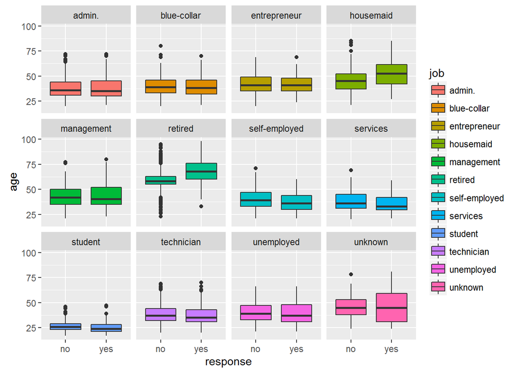

```r
ggplot(m2, aes(x = response, y = age , fill = job )) + geom_boxplot() +
  facet_wrap(~ job, ncol = 4)
```

So as to analyse the profession and age group which has the highest no. of subscriptions.

**Logistic Regression**

```r
#Independent variables
age<- m2$age
job<- m2$job
martial<-m2$marital
education<-m2$education
default<-m2$default
housing<-m2$housing
loan <- m2$loan

# Dependent variable
response<-m2$response

#Generating labels
l_job<-rbind(levels(job))
l_martial<-rbind(levels(martial))
l_education<-rbind(levels(education))
l_default<-rbind(levels(default))
l_housing<-rbind(levels(housing))
l_loan<-rbind(levels(loan))


#Factoring variables
f.job<-factor(job,labels=l_job)
f.martial<-factor(martial,labels=l_martial)
f.education<-factor(education,labels=l_education)
f.default<-factor(default,labels=l_default)
f.housing<-factor(housing,labels=l_housing)
f.loan<-factor(loan,labels=l_loan)



# Create Contras matrix#
contrasts(f.job) = contr.treatment(length(levels(job)))
contrasts(f.martial) = contr.treatment(length(levels(martial)))
contrasts(f.education) = contr.treatment(length(levels(education)))
contrasts(f.default) = contr.treatment(length(levels(default)))
contrasts(f.housing) = contr.treatment(length(levels(housing)))
contrasts(f.loan) = contr.treatment(length(levels(loan)))



#Model_1
Model_1 <- glm(response ~ age + f.job +f.martial +f.education +f.default+f.default
               +f.housing+f.loan, data=m2  ,family = binomial("logit"))
summary(Model_1)
```

```
##
## Call:
## glm(formula = response ~ age + f.job + f.martial + f.education +
##     f.default + f.default + f.housing + f.loan, family = binomial("logit"),
##     data = m2)
##
## Deviance Residuals:
##     Min       1Q   Median       3Q      Max
## -1.1088  -0.5252  -0.4523  -0.3302   2.7355
##
## Coefficients: (1 not defined because of singularities)
##               Estimate Std. Error z value Pr(>|z|)
## (Intercept)  -2.711864   0.127037 -21.347  < 2e-16 ***
## age           0.014319   0.001925   7.439 1.02e-13 ***
## f.job2       -0.380171   0.062567  -6.076 1.23e-09 ***
## f.job3       -0.378287   0.099795  -3.791  0.00015 ***
## f.job4       -0.128138   0.112300  -1.141  0.25386
## f.job5       -0.185278   0.067068  -2.763  0.00574 **
## f.job6        0.714086   0.079687   8.961  < 2e-16 ***
## f.job7       -0.192854   0.092621  -2.082  0.03733 *
## f.job8       -0.304591   0.069006  -4.414 1.01e-05 ***
## f.job9        1.180574   0.085929  13.739  < 2e-16 ***
## f.job10      -0.165880   0.055155  -3.008  0.00263 **
## f.job11       0.261646   0.096673   2.706  0.00680 **
## f.job12       0.002440   0.183210   0.013  0.98938
## f.martial2    0.141883   0.054080   2.624  0.00870 **
## f.martial3    0.422868   0.060882   6.946 3.77e-12 ***
## f.martial4    0.429426   0.322763   1.330  0.18336
## f.education2  0.005580   0.095429   0.058  0.95337
## f.education3 -0.154831   0.074816  -2.069  0.03850 *
## f.education4 -0.043379   0.071794  -0.604  0.54571
## f.education5  1.018564   0.583695   1.745  0.08098 .
## f.education6  0.045028   0.079045   0.570  0.56891
## f.education7  0.176785   0.071216   2.482  0.01305 *
## f.education8  0.229515   0.092575   2.479  0.01317 *
## f.default2   -0.943032   0.053228 -17.717  < 2e-16 ***
## f.default3   -8.613761  68.964693  -0.125  0.90060
## f.housing2   -0.005653   0.107315  -0.053  0.95799
## f.housing3    0.056639   0.032340   1.751  0.07989 .
## f.loan2             NA         NA      NA       NA
## f.loan3      -0.056417   0.044879  -1.257  0.20872
## ---
## Signif. codes:  0 '***' 0.001 '**' 0.01 '*' 0.05 '.' 0.1 ' ' 1
##
## (Dispersion parameter for binomial family taken to be 1)
##
##     Null deviance: 28999  on 41187  degrees of freedom
## Residual deviance: 27659  on 41160  degrees of freedom
## AIC: 27715
##
## Number of Fisher Scoring iterations: 9
```

After generating a linear model of the dependent variable w.r.t the variables. The accuracy of the model generated is accessed. So as to evaluate the model.

```r
#Accuracy of the Model_1 after prediction
in_d <- data.frame(age,job,martial,education,default,housing,loan, response)
predicted_response<-round(predict(Model_1,in_d,type="response"))
confusion_matrix <- ftable(response, predicted_response)
accuracy <- sum(diag(confusion_matrix))/41188*100
accuracy
```

```
## [1] 88.73458
```

**Accuracy** is found to be 88.7345829.’. Techinically the model can be used to predict the response with that accuracy.

**Using Rpart to make a decision tree**

[figure not shown]

```r
fit = rpart(response ~ ., data = myy, method = "class")

fancyRpartPlot(fit, main = "Decision Tree of the dependent variable, Response")
```

**Lets evaluate the accuracy of the decision tree**

```r
pp = predict(fit, myy, type = "class")

st <- data.frame(age = myy$age, response = pp)

ct <- ftable(response, pp)
ay <- sum(diag(ct))/41188*100
ay
```

```
## [1] 91.28387
```

**Accuracy** is found to be 91.2838691.’.

The accuracy is even more than the accuracy of linear model generated. Hence, it is highly recommeded to make sure the attributes lie within the positive decision tree so as to get a positive response.

For previous insights please visit [Gramener.Assigment](https://github.com/STrikEr-TejaS/Gramener_Assignment)